# Assignment 3

Pine Nguyen

2025-09-01

## Prepare the data set

```r
library(tidyverse)
library(lubridate)
library(janitor)
```

**Question 1** Load the CSV, graph “Number of Complaints per Month (based on Received Date)” using a line chart.

This script loads libraries for cleaning, dates, and visualization, reads the Insurance_complaints.csv file without headers, and assigns consistent column names. It converts complaint dates into proper formats, groups data by received month, counts complaints per month, and creates a line chart showing complaint trends over time with six-month intervals on the x-axis.

```r
library(readr)

data <- read_csv('C:\\Users\\User\\Downloads\\Project\\Insurance_complaints.csv', col_names = FALSE, show_col_types = FALSE)
```

```r
# The file has 17 columns.
names(data) <- c(
  "complaint_id",
  "company",
  "party_type",
  "reason",
  "catastrophe_flag",
  "notes",
  "received_date",
  "closed_date",
  "line_of_insurance",
  "coverage_type",
  "coverage_type_2",
  "associated_party",
  "naic_code",
  "license_status",
  "org_type",
  "person_type",
  "topics"
)
```

```r
# Make syntactically clean names
data <- janitor::clean_names(data)
```

```r
# Parse dates (use ymd, not mdy)
data <- data %>%
  mutate(
    received_date = ymd(received_date),
    closed_date   = ymd(closed_date)
  )
```

```r
# Build the monthly series from received_date
monthly <- data %>%
  filter(!is.na(received_date)) %>%
  mutate(month = floor_date(received_date, "month")) %>%
  count(month, name = "complaints") %>%
  arrange(month)
```

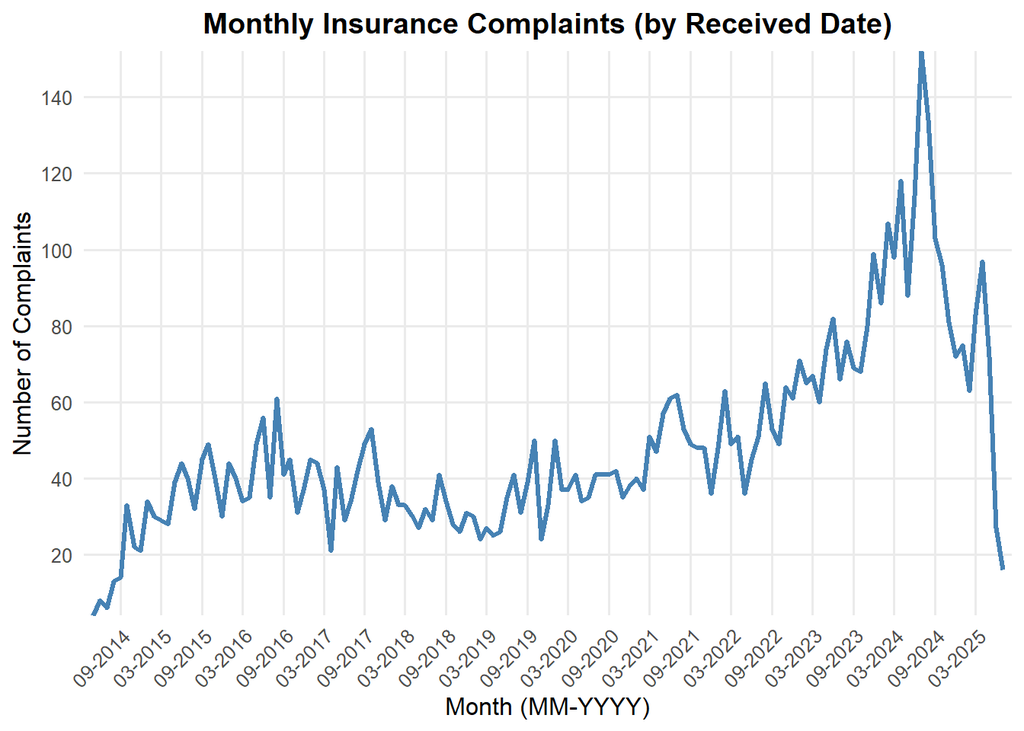

```r
# 4) Plot
ggplot(monthly, aes(x = month, y = complaints)) +
  geom_line(color = "steelblue", linewidth = 1.2) +
  labs(
    title = "Monthly Insurance Complaints (by Received Date)",
    x = "Month (MM-YYYY)",
    y = "Number of Complaints"
  ) +
  scale_x_date(
    date_breaks = "6 months",
    date_labels = "%m-%Y",
    expand = c(0.01, 0.01)
  ) +
  scale_y_continuous(
    expand = c(0, 0),
    breaks = scales::pretty_breaks(n = 8)
  ) +
  theme_minimal(base_size = 12) +
  theme(
    axis.text.x = element_text(angle = 45, hjust = 1),
    plot.title = element_text(face = "bold", hjust = 0.5),
    panel.grid.minor = element_blank()
  )
```

**Question 2** Perform statistical calculation, select relevant columns to analyze, create a graph, and explain what the result shows about your question.

We’ll calculate the average complaint resolution time for each company by subtracting the complaint’s received date from its closed date. Then, we summarize the results and visualize the top 5 companies with a bar chart to compare how quickly each one resolves complaints.

```r
# Calculate resolution days
resolution <- data %>%
  filter(!is.na(received_date) & !is.na(closed_date)) %>%
  mutate(resolution_days = as.numeric(closed_date - received_date)) %>%
  group_by(company) %>%
  summarise(
    avg_resolution = mean(resolution_days, na.rm = TRUE),
    n_complaints = n()
  ) %>%
  arrange(avg_resolution)
```

This gives a table of average resolution time (in days) per company.And then a bar chart makes this easy to compare across companies:

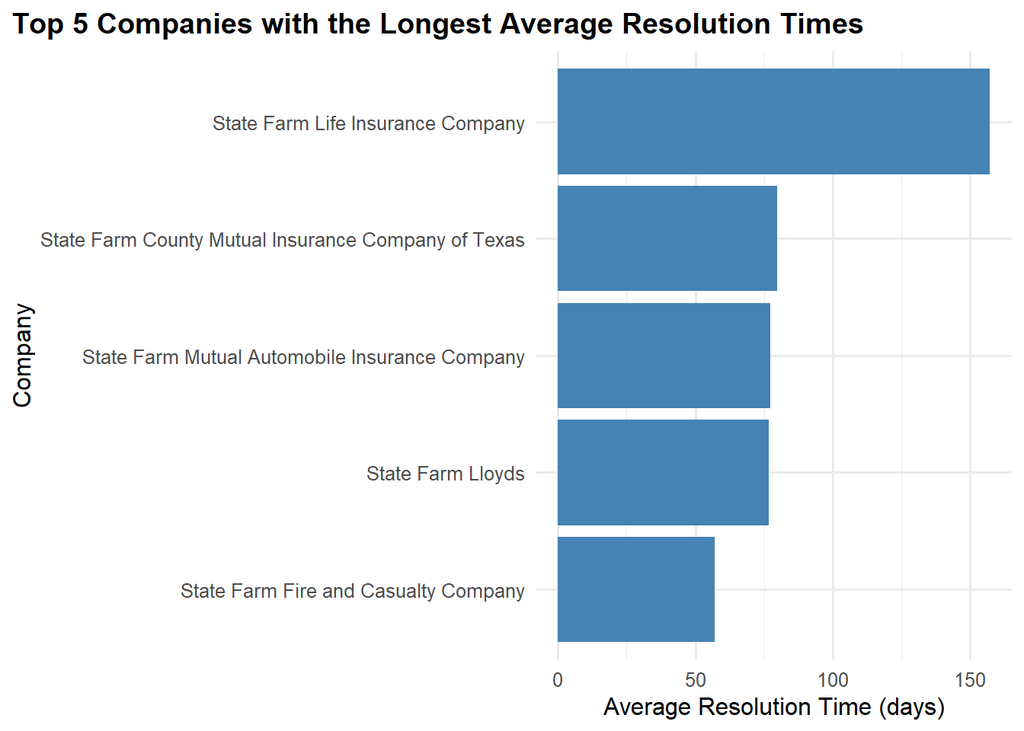

```r
# keep only top 5 companies by avg_resolution
top10 <- resolution %>%
  slice_max(avg_resolution, n = 5)

ggplot(top10, aes(x = reorder(company, avg_resolution), y = avg_resolution)) +
  geom_col(fill = "steelblue") +
  coord_flip() +
  labs(
    title = "Top 5 Companies with the Longest Average Resolution Times",
    x = "Company",
    y = "Average Resolution Time (days)"
  ) +
  theme_minimal(base_size = 12) +
  theme(
   plot.title.position = "plot",
    plot.title = element_text(face = "bold", hjust = 0)  )
```

The results show that State Farm Life Insurance Company has the slowest resolution speed, taking over 150 days on average to close complaints, while State Farm Fire and Casualty Company resolves them much faster, averaging just over 50 days. This indicates that complaint resolution efficiency varies widely across different State Farm branches, with some companies being significantly faster than others in addressing customer issues.

**Question 3:** Is there a relationship between the number of complaints a company receives and how long it takes them to resolve complaints?

Hypothesis: Companies that handle more complaints may take longer (positive correlation), or may be more efficient (negative correlation).

```r
# Compute resolution days for each complaint
resolution_data <- data %>%
  filter(!is.na(received_date) & !is.na(closed_date)) %>%
  mutate(resolution_days = as.numeric(closed_date - received_date))

# Aggregate by company: average resolution time & number of complaints
company_summary <- resolution_data %>%
  group_by(company) %>%
  summarise(
    avg_resolution = mean(resolution_days, na.rm = TRUE),
    complaint_count = n()
  )
```

```r
# Correlation
cor_test <- cor.test(company_summary$complaint_count, company_summary$avg_resolution)

# Regression
model <- lm(avg_resolution ~ complaint_count, data = company_summary)
summary(model)
```

```
##
## Call:
## lm(formula = avg_resolution ~ complaint_count, data = company_summary)
##
## Residuals:
##       1       2       3       4       5
## -17.252 -40.948  58.528  -5.836   5.509
##
## Coefficients:
##                  Estimate Std. Error t value Pr(>|t|)
## (Intercept)     98.762324  25.126727   3.931   0.0293 *
## complaint_count -0.007017   0.012463  -0.563   0.6128
## ---
## Signif. codes:  0 '***' 0.001 '**' 0.01 '*' 0.05 '.' 0.1 ' ' 1
##
## Residual standard error: 42.68 on 3 degrees of freedom
## Multiple R-squared:  0.09555,    Adjusted R-squared:  -0.2059
## F-statistic: 0.3169 on 1 and 3 DF,  p-value: 0.6128
```

- The slope for complaint_count is -0.007, with a p-value = 0.61.
- That means there is no statistically significant relationship between how many complaints a company gets and how long they take to resolve them.
- The R² = 0.096 is very low, showing the model explains almost none of the variation in resolution time.

Complaint volume does not predict resolution time in this dataset.

**Question 3:** For complaints filed against State Farm, is a higher monthly complaint volume associated with longer average resolution times?

We will calculate how long each took to resolve, and then summarize the average resolution time and number of complaints by month. It tests whether months with more complaints tend to have longer or shorter resolution times using correlation and linear regression. Finally, we create a scatter plot with a regression line and displays the key statistics (correlation, p-value, slope, and R²) directly on the chart.

```r
library(dplyr)
library(ggplot2)
library(lubridate)

state_monthly <- data %>%
  filter(!is.na(company),
         grepl("state\\s*farm", tolower(company))) %>%
  mutate(
    received_date = ymd(received_date),
    closed_date   = ymd(closed_date),
    resolution_days = as.numeric(closed_date - received_date),
    month = floor_date(received_date, "month")
  ) %>%
  filter(is.finite(resolution_days), resolution_days >= 0) %>%
  group_by(month) %>%
  summarise(
    complaints = n(),
    avg_days   = mean(resolution_days, na.rm = TRUE),
    .groups = "drop"
  ) %>%
  filter(complaints >= 5) %>%
  arrange(month)


# --- Correlation and simple linear regression
cor_test_sf <- cor.test(state_monthly$complaints, state_monthly$avg_days, method = "pearson")
lm_sf <- lm(avg_days ~ complaints, data = state_monthly)
cor_test_sf      # prints r and p-value
```

```
##
##  Pearson's product-moment correlation
##
## data:  state_monthly$complaints and state_monthly$avg_days
## t = -2.0481, df = 132, p-value = 0.04253
## alternative hypothesis: true correlation is not equal to 0
## 95 percent confidence interval:
##  -0.335111262 -0.006089325
## sample estimates:
##        cor
## -0.1754965
```

```r
summary(lm_sf)   # prints slope and R^2
```

```
##
## Call:
## lm(formula = avg_days ~ complaints, data = state_monthly)
##
## Residuals:
##     Min      1Q  Median      3Q     Max
## -64.864 -25.366   5.665  28.260  66.844
##
## Coefficients:
##             Estimate Std. Error t value Pr(>|t|)
## (Intercept)  92.3604     6.6794  13.828   <2e-16 ***
## complaints   -0.2498     0.1219  -2.048   0.0425 *
## ---
## Signif. codes:  0 '***' 0.001 '**' 0.01 '*' 0.05 '.' 0.1 ' ' 1
##
## Residual standard error: 34.84 on 132 degrees of freedom
## Multiple R-squared:  0.0308, Adjusted R-squared:  0.02346
## F-statistic: 4.195 on 1 and 132 DF,  p-value: 0.04253
```

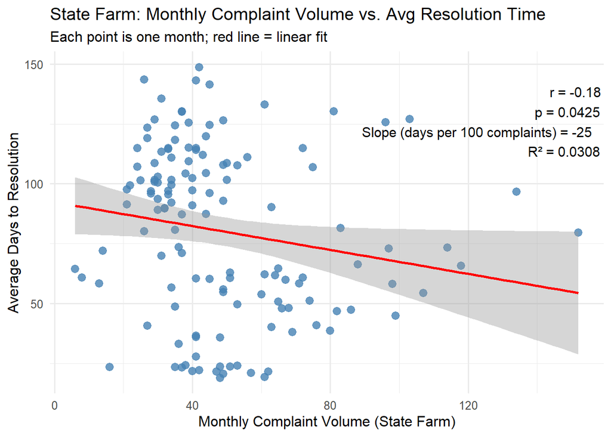

```r
# --- Scatter plot with regression line and on-plot stats
ggplot(state_monthly, aes(x = complaints, y = avg_days)) +
  geom_point(size = 2.8, alpha = 0.8, color = "steelblue") +
  geom_smooth(method = "lm", se = TRUE, color = "red") +
  labs(
    title = "State Farm: Monthly Complaint Volume vs. Avg Resolution Time",
    subtitle = "Each point is one month; red line = linear fit",
    x = "Monthly Complaint Volume (State Farm)",
    y = "Average Days to Resolution"
  ) +
  annotate(
    "text",
    x = Inf, y = Inf, hjust = 1.05, vjust = 1.5, size = 4,
    label = paste0(
      "r = ", round(cor_test_sf$estimate, 2),
      "\np = ", signif(cor_test_sf$p.value, 3),
      "\nSlope (days per 100 complaints) = ",
      round(100 * coef(lm_sf)["complaints"], 1),
      "\nR² = ", signif(summary(lm_sf)$r.squared, 3)
    )
  ) +
  theme_minimal(base_size = 12)
```